# Analysis Script for Visual Occlusion

Xueyi Huang

2024-08-15

## Documentation

Must be run from within the repo’s branch folder.

[output not shown]

## v08_move_to_middle

This experiment tests the visual occlusion effect in mental imagery by using a priming paradigm following Sekuler and Palmer (1992). If subjects are primed by a circle, and then do a same/ different task. they are faster to determine two circles are the same rather than two Pac-Men are the same. If the prime is a Pac-Man, they are faster in the two Pac-Men test. When we see a shape like “Pac-Man” and a square fits perfectly into the missing quarter, our brain fills in the missing part. This makes us perceive the square as if it is overlaid on a complete circle rather than next to a Pac-Man so that it can prime the two circles discrimination task instead of the two Pac-Men condition. We predict this is the same in mental imagery: an imagined partially occluded notched shape is presented as complete. V08 is a control experiment. We ask subjects to imagine moving a corner shape up/down, aligning it with the central shape side by side.

### Experiment

https://xh.subjectivityresearch.org/visual_occlusion/v08_move_to_middle/index.html

### Stimuli and Task Design

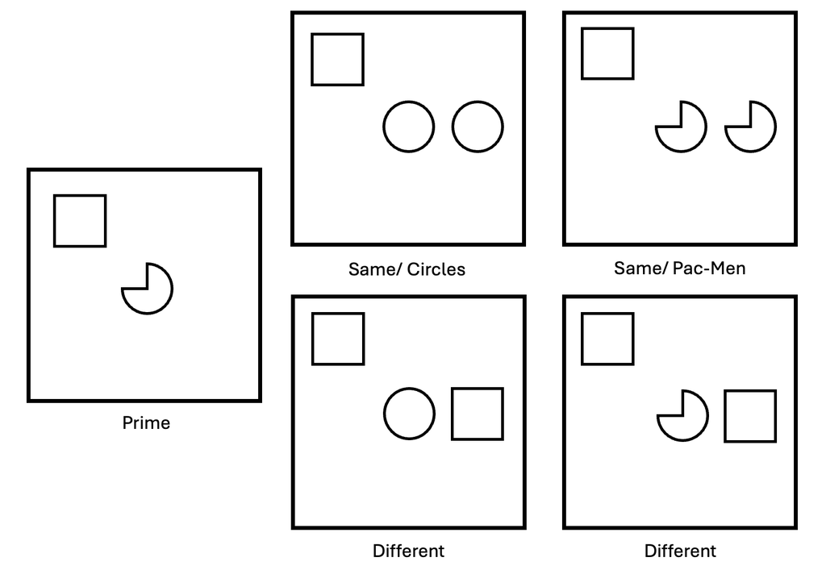

```r
knitr::include_graphics("image/procedure.png")
```

In this task, each trial begins with a fixation cross appearing in the center of the screen for 250 ms, followed by a 250 ms blank screen. Next, a prime display is shown for 1000 ms, featuring a centered prime shape (either a notched square or a Pac-Man) with an occluder (either a circle or a square) positioned at one of the screen’s four corners. This arrangement results in eight possible types of prime displays. This prime disappears after 1000 ms, leaving an empty screen. Subjects need to imagine the corner shape moving up/down to the middle. Then a test display appears, containing three shapes: an irrelevant shape that mimics the occluder and is positioned further from the center, and a test pair of two shapes in the middle of the screen. The task requires subjects to determine if the test pair shapes are the same or different (key ‘S’ for ‘same’ and key ‘D’ for ‘different’). The same condition includes either two identical shapes (e.g., two circles or two Pac-Men for Pac-Man primes, or two squares or two notched squares for notched square primes), while the different condition includes a pair of different shapes (e.g., a circle and a square or a Pac-Man and a square for Pac-Man primes, or a square and a circle or a notched square and a circle for notched square primes). Feedback is provided based on the response time (RT): if the RT exceeds 1500 ms, a warning message “TOO SLOW! Press the spacebar to continue.” appears, and if the RT is faster than 200 ms, a message “Do not press before the test shapes appear. Press the spacebar to continue.” is displayed. Finally they need to click the button with their mouse to rate the vividness of their mental imagery. 1 = Not vivid at all, 2 = Slightly vivid, 3 = Moderately vivid, 4 = Very vivid, 5 = Extremely vivid. The next trial begins automatically after a 1000 ms delay.

The stimuli box measures 400 pixels, with shapes having a diameter of 67 pixels. In the test display, the irrelevant shape is positioned 58 pixels from the left and 58 pixels from the top, with the test pair shapes spaced 89 pixels apart.

### Parameters

- const itiDuration = 1000; //ms
- const fixationDuration = 250; //ms
- const imageDuration = 1000; //ms
- const imageryDuration = 3000; //ms
- const maxResponseTime = 1500; //ms
- const afterFixationInterval = 250; //ms

### Subjects

- Platform: Prolific
- 14 Aug 2024, 15:48
- 50 subjects
- Age: 18–65
- Current Country of Residence: United Kingdom, United States
- Normal vision, no Colorblindness, and no mild cognitive impairment/Dementia
- Approval Rate: 99–100
- Number of previous submissions: 50–10000
- ~13 minutes (with instructions and questionnaires)
- Total study cost: $173.33
- Study code: C19E4WDH

### Key Columns for Analysis

- Subject: exclude participants with low accuracy (46 left) and outliers (45 left).
- trialNum: 32 trials per subject.
- test_shape: complete or notched.
- prime_shape: circle or square.
- correct_answer: same or different (only analyze “same”).
- correct: 0 means incorrect (either slow or press the wrong key); 1 means correct (only analyze “correct”).
- rt: calculate the mean rt of each condition.